# Final Project

## Decision Tree

we will first creat the instance of DecisionTreeClassifier called **heart_tree**

Inside of the classifier we also specify criterion="entropy" so we can see the information gain of each node.

```python
heart_tree = DecisionTreeClassifier(criterion = "entropy", max_depth = 4)
heart_tree
```

```
DecisionTreeClassifier(ccp_alpha=0.0, class_weight=None, criterion='entropy',
                       max_depth=4, max_features=None, max_leaf_nodes=None,
                       min_impurity_decrease=0.0, min_impurity_split=None,
                       min_samples_leaf=1, min_samples_split=2,
                       min_weight_fraction_leaf=0.0, presort='deprecated',
                       random_state=None, splitter='best')
```

```python
heart_tree.fit(X_train,Y_train)
pred_tree = heart_tree.predict(X_test)
pred_tree[0:5]
```

```
array([0, 0, 1, 1, 1], dtype=int64)
```

```python
print (pred_tree [0:5])
print (Y_test [0:5])
```

```
[0 0 1 1 1]
[1 0 1 1 0]
```

**Evaluation**

```python
from sklearn import metrics
print("DecisionTree's Train set Accuracy: ", metrics.accuracy_score(Y_train, heart_tree.predict(X_train)).round(3)*100)
print("DecisionTrees's Test set Accuracy: ", metrics.accuracy_score(Y_test, pred_tree).round(4)*100)
```

```
DecisionTree's Train set Accuracy:  86.8
DecisionTrees's Test set Accuracy:  85.25
```

### Classification report for Decision tree classifier

```python
from sklearn.metrics import classification_report
print (classification_report(Y_test, pred_tree))
```

```
              precision    recall  f1-score   support

           0       0.86      0.76      0.81        25
           1       0.85      0.92      0.88        36

    accuracy                           0.85        61
   macro avg       0.85      0.84      0.84        61
weighted avg       0.85      0.85      0.85        61
```

### Decision tree algorithm predict the target class variable with 85.25 % accuracy for our dataset df.

## Logistic Regression

```python
X[0:5]
```

```
array([[ 0.9521966 ,  0.68100522,  1.97312292,  0.76395577, -0.25633371,
         2.394438  , -1.00583187,  0.01544279, -0.69663055,  1.08733806,
        -2.27457861, -0.71442887, -2.14887271],
       [-1.91531289,  0.68100522,  1.00257707, -0.09273778,  0.07219949,
        -0.41763453,  0.89896224,  1.63347147, -0.69663055,  2.12257273,
        -2.27457861, -0.71442887, -0.51292188],
       [-1.47415758, -1.46841752,  0.03203122, -0.09273778, -0.81677269,
        -0.41763453, -1.00583187,  0.97751389, -0.69663055,  0.31091206,
         0.97635214, -0.71442887, -0.51292188],
       [ 0.18017482,  0.68100522,  0.03203122, -0.66386682, -0.19835726,
        -0.41763453,  0.89896224,  1.23989692, -0.69663055, -0.20670527,
         0.97635214, -0.71442887, -0.51292188],
       [ 0.29046364, -1.46841752, -0.93851463, -0.66386682,  2.08204965,
        -0.41763453,  0.89896224,  0.58393935,  1.43548113, -0.37924438,
         0.97635214, -0.71442887, -0.51292188]])
```

```python
Y[0:5]
```

```
array([1, 1, 1, 1, 1], dtype=int64)
```

The version of Logistic Regression in Scikit-learn, support regularization. Regularization is a technique used to solve the overfitting problem in machine learning models. C parameter indicates inverse of regularization strength which must be a positive float. Smaller values specify stronger regularization. Now lets fit our model with train set:

```python
LR = LogisticRegression(C=0.01, solver='liblinear').fit(X_train,Y_train)
LR
```

```
LogisticRegression(C=0.01, class_weight=None, dual=False, fit_intercept=True,
                   intercept_scaling=1, l1_ratio=None, max_iter=100,
                   multi_class='auto', n_jobs=None, penalty='l2',
                   random_state=None, solver='liblinear', tol=0.0001, verbose=0,
                   warm_start=False)
```

Now we predict using our test set

```python
yhat_L = LR.predict(X_test)
print(Y_test)
yhat_L
```

```
[1 0 1 1 0 0 0 1 1 1 1 1 1 0 1 0 1 1 0 0 1 1 0 1 1 0 0 1 1 0 0 1 1 1 0 1 1
 1 0 0 0 0 0 1 1 1 0 0 0 1 0 1 1 1 1 1 1 1 0 0 1]
```

```
array([1, 0, 1, 1, 1, 0, 0, 1, 1, 1, 1, 1, 1, 0, 1, 0, 1, 1, 0, 1, 1, 1,
       0, 1, 1, 0, 0, 1, 1, 0, 0, 0, 1, 1, 1, 1, 1, 1, 1, 0, 0, 0, 0, 1,
       1, 1, 0, 0, 0, 1, 0, 1, 0, 0, 1, 1, 1, 1, 0, 0, 1], dtype=int64)
```

```python
yhat_prob = LR.predict_proba(X_test)
yhat_prob[0:5]
```

```
array([[0.37631007, 0.62368993],
       [0.72008853, 0.27991147],
       [0.40239548, 0.59760452],
       [0.19110398, 0.80889602],
       [0.40269454, 0.59730546]])
```

### Model Accuracy evaluation

```python
test_score = accuracy_score(Y_train, LR.predict(X_train)).round(3) * 100
train_score = accuracy_score(Y_test, LR.predict(X_test)).round(3) * 100
print("Logistic Regression Train set Accuracy: ",test_score)
print("Logistic Regression Test set Accuracy: ",train_score)
```

```
Logistic Regression Train set Accuracy:  85.1
Logistic Regression Test set Accuracy:  88.5
```

```python
from sklearn.metrics import classification_report
print (classification_report(Y_test, yhat_L))
```

```
              precision    recall  f1-score   support

           0       0.88      0.84      0.86        25
           1       0.89      0.92      0.90        36

    accuracy                           0.89        61
   macro avg       0.88      0.88      0.88        61
weighted avg       0.88      0.89      0.88        61
```

### Confusion Matrix

```python
cm_L = confusion_matrix(Y_test, yhat_L)
```

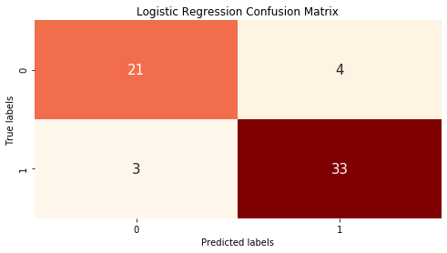

```python
plt.title("Logistic Regression Confusion Matrix")

sns.heatmap(cm_L, annot = True, cmap = "OrRd", cbar = False, annot_kws = {"size":15})
plt.xlabel('Predicted labels');plt.ylabel('True labels');
plt.show()
```

Precision is a measure of the accuracy provided that a class label has been predicted. It is defined by: precision = TP / (TP + FP)

Recall is true positive rate. It is defined as: Recall = TP / (TP + FN)

So, we can calculate precision and recall of each class.

F1 score: Now we are in the position to calculate the F1 scores for each label based on the precision and recall of that label.

The F1score is the harmonic average of the precision and recall, where an F1 score reaches its best value at 1 (perfect precision and recall) and worst at 0. It is a good way to show that a classifer has a good value for both recall and precision.

### Log loss

In logistic regression, the output can be the probability of chance of infection is yes (or equals to 1). This probability is a value between 0 and 1. Log loss( Logarithmic loss) measures the performance of a classifier where the predicted output is a probability value between 0 and 1. Lesser the value of log loss, more accurate is the model.

```python
log_loss(Y_test, yhat_prob)
```

```
0.4363789674264379
```

## Model comparisions using confusion Matrix

```python
cm_knn = confusion_matrix(Y_test,yhat_)
cm_dtc = confusion_matrix(Y_test,pred_tree)
cm_L = confusion_matrix(Y_test,yhat_L)
```

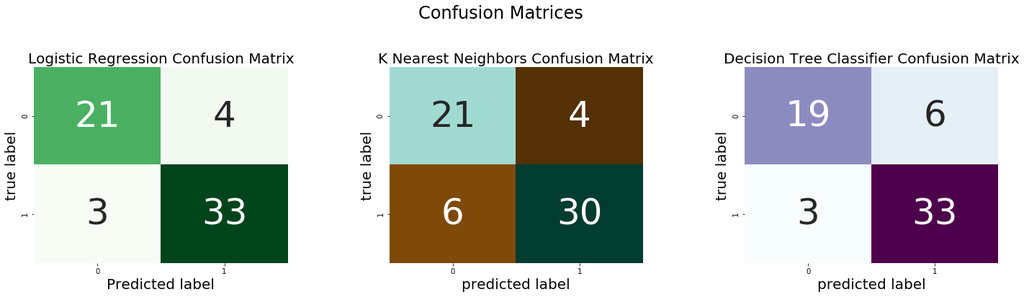

```python
plt.figure(figsize=(24,12))

plt.suptitle("Confusion Matrices",fontsize=24)
plt.subplots_adjust(wspace = 0.4, hspace= 0.4)

plt.subplot(2,3,1)
plt.title("Logistic Regression Confusion Matrix", fontsize = 20)
sns.heatmap(cm_L,annot=True,cmap="Greens",fmt="d",cbar=False, annot_kws={"size": 50})
plt.xlabel("Predicted label", fontsize = 20)
plt.ylabel("true label", fontsize = 20)

plt.subplot(2,3,2)
plt.title("K Nearest Neighbors Confusion Matrix", fontsize = 20)
sns.heatmap(cm_knn,annot=True,cmap="BrBG",fmt="d",cbar=False, annot_kws={"size": 50})
plt.xlabel("predicted label", fontsize = 20)
plt.ylabel("true label", fontsize = 20)

plt.subplot(2,3,3)
plt.title("Decision Tree Classifier Confusion Matrix", fontsize = 20)
sns.heatmap(cm_dtc,annot=True,cmap="BuPu",fmt="d",cbar=False, annot_kws={"size": 50})
plt.xlabel("predicted label", fontsize = 20)
plt.ylabel("true label", fontsize = 20)

plt.show()
```